# Script 05: Differential Gene Expression analysis

Steps involved:

1. DEGs on cell-level data
2. Heatmaps of log-normalized z-scaled counts
3. DEGs on pseudosample-level data

```r
library(Seurat)
library(dplyr)
library(patchwork)
library(ggplot2)
library(ComplexHeatmap)
library(RColorBrewer)
library(edgeR)
```

Load a couple of helper functions:

```r
source("R/plotting.R")
source("R/quickndirty_helpers.R")
```

Paths:

```r
# path to full integration result (04) in the form of a seurat object:
data_path <- file.path("results", "29_REVIEW_integrated_final_label", "29_reviewed_integrated_object.rds")
# results:
results_path <- file.path("05_DEGs")
if(!dir.exists(results_path)){
  dir.create(results_path, recursive = TRUE)
}
```

# Cell-level DEGs (Wilcoxon rank-sum)

Load the integrated object

```r
seurat_obj <- readRDS(data_path)
seurat_obj <- NormalizeData(seurat_obj)
```

```
## Normalizing layer: counts
```

### Run pairwise comparisons for the aberrant vs non-aberrant populations

```r
Idents(seurat_obj) <- seurat_obj$final_label

# pairs of interest
pairs <- list(
  c("GMPs (granulocytic)-like", "GMPs (granulocytic)"),
  c("Promonocytes-like", "Promonocytes"),
  c("Monocytes-like", "Monocytes")
  )

# run findmarkers over list
results_list <- lapply(
  pairs,
  find_markers_for_pair,
  seurat_obj = seurat_obj,
  gene_of_interest = "Prtn3",
  min_pct = 0.25,
  min_diff_pct = 0.1,
  out_dir = file.path(results_path, "marker_outputs")
  )
```

```r
print(head(results_list[[2]], n = 10))
```

```
##                  p_val avg_log2FC pct.1 pct.2     p_val_adj
## Ifitm1   1.592254e-241   4.695302 0.769 0.097 5.365259e-237
## Tmem176b 2.712043e-219   2.612387 0.844 0.296 9.138502e-215
## Selenom  2.158582e-197   2.633670 0.811 0.319 7.273557e-193
## Cd24a    3.975731e-184   1.825279 0.901 0.505 1.339662e-179
## Ms4a3    8.171872e-153   2.032895 0.809 0.357 2.753594e-148
## Pglyrp1  7.035045e-146   2.356829 0.800 0.238 2.370529e-141
## S100a8   1.947873e-136   2.153137 0.773 0.181 6.563554e-132
## Tmem176a 2.896875e-134   2.059464 0.725 0.281 9.761309e-130
## Prtn3    4.437713e-134   1.043409 0.986 0.841 1.495332e-129
## Ptms     1.189137e-130   1.671211 0.830 0.474 4.006917e-126
```

### Run pairwise comparisons in (shared) HSPCs for the different genotypes

```r
# subset for only hspcs
subset_hspc <- subset(
  seurat_obj,
  subset = overall_class == "shared HSPCs"
  )

Idents(subset_hspc) <- subset_hspc$genotype

# get genotype pairs
pairs <- combn(
  unique(subset_hspc$genotype),
  2,
  simplify = FALSE
  )

# run findmarkers over pairs
results_list_hspc <- lapply(
  pairs,
  find_markers_for_pair,
  seurat_obj = subset_hspc,
  gene_of_interest = "Prtn3",
  min_pct = 0.25,
  min_diff_pct = 0.1,
  out_dir = file.path(results_path, "marker_outputs_HSPC")
)
```

### Draw heatmaps

Select celltypes to compare:

```r
# I'll run with HSPCs: ko vs ctrl for this example
cell_types <- c("shared HSPCs")
current_comp <- "HSPCs_by_genotype"
current_markers <- results_list_hspc[[2]]
```

Select wether to clamp outier values (by q5 / q95):

```r
clip <- TRUE
upper_q = 0.95
lower_q = 0.05
```

```r
# boolean indexing (seurat subset() causes problems since v5 for me)
genes_idx <- rownames(seurat_obj) %in% rownames(current_markers[1:10,])
cell_idx <- seurat_obj$overall_class %in% cell_types # use final_label column for aberrant vs non-aberrant

# get matrix
mat <- seurat_obj[["RNA"]]@layers$data[genes_idx, cell_idx] %>%
  as.matrix()

# rename dimensions
rownames(mat) <- rownames(seurat_obj)[genes_idx]
colnames(mat) <- colnames(seurat_obj)[cell_idx]

# feature z-scaling
mat <- t(scale(t(mat)))

# OPTIONAL: clip outliers
if(clip){
  lower_cap <- quantile(mat, lower_q)
  upper_cap <- quantile(mat, upper_q)
}
mat[mat < lower_cap] <- lower_cap
mat[mat > upper_cap] <- upper_cap
```

Construct heatmap:

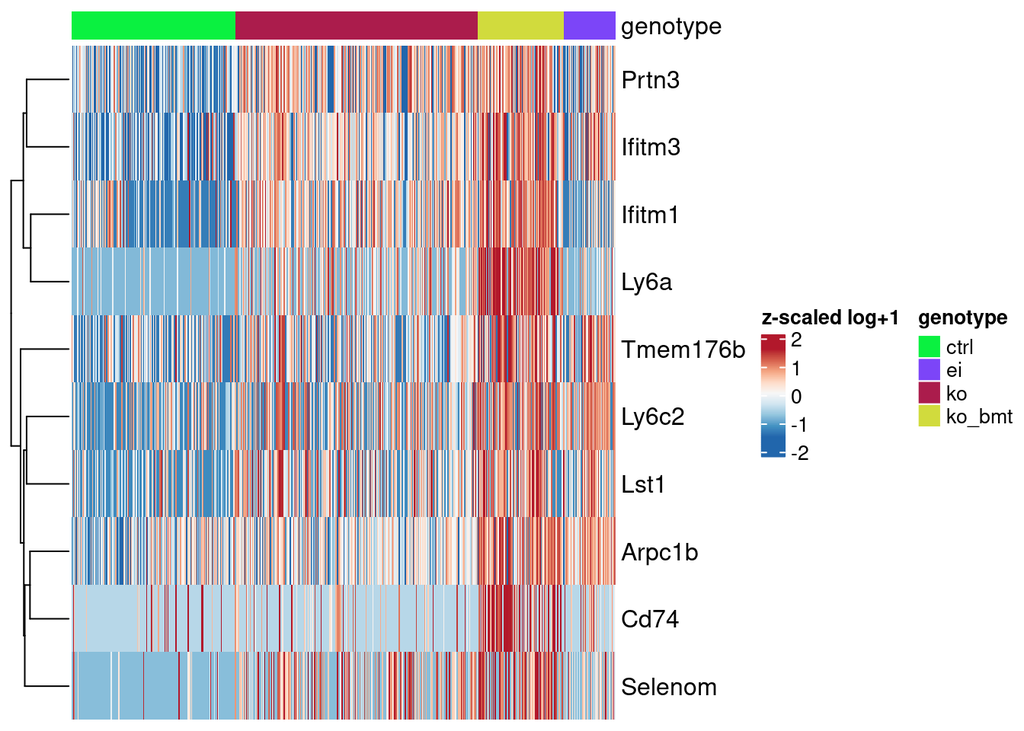

```r
top_anno <- HeatmapAnnotation(
  df = seurat_obj@meta.data %>%
    filter(cell_idx) %>%
    select(genotype)
  )

ht <- Heatmap(mat,
              name = "z-scaled log+1",
              #column_split = factor(separation),
              cluster_column_slices = FALSE,
              column_title_gp = gpar(fontsize = 16),
              show_column_dend = FALSE,
              #column_gap = unit(0.5, "mm"),
              cluster_columns = FALSE,
              cluster_rows = TRUE,
              show_row_dend = TRUE,
              col = rev(brewer.pal(n = 9, name = "RdBu")),
              row_names_gp = gpar(fontsize = 12),
              top_annotation = top_anno,
              show_column_names = FALSE,
              use_raster = TRUE,
              raster_quality = 4)

draw(ht)
```

```r
# pdf(file.path(results_path, paste0(current_comp, "_top10.pdf")),
#     width = std_width,
#     height = std_height)
# dev.off()
```

# Pseudo-bulk analyses of HSPCs

scRNA-seq DEG calling can be prone to false positives. Pseudobulk analyses have been shown to be more robust, with likelihood ratio testing performing best. We will enhance our DEG calling in the case of HSPCs by aggregating pseudosamples (1 sample = 1 murine donor) and testing for significance using edgeR-LRT. This code can be adapted for other cell type comparisons

### Wrangle counts & metadata

Count cells & aggregate:

```r
# track cell numbers
cell_counts_hspcs <- subset(
  seurat_obj@meta.data,
  overall_class == "shared HSPCs") %>%
  group_by(genotype, mouse_id) %>%
  summarise(n_cells = n(), .groups = "drop") %>%
  mutate(sample_id = as.character(mouse_id))

# aggregate read counts
agg_hspcs <- AggregateExpression(
  subset(seurat_obj,
         subset = overall_class == "shared HSPCs"),
  group.by = c("genotype", "mouse_id"))$RNA
```

```
## Names of identity class contain underscores ('_'), replacing with dashes ('-')
```

```r
print(dim(agg_hspcs))
```

```
## [1] 33696    13
```

Create sample-level metadata table:

```r
# initiate df
samples_df <- data.frame()

# populate df
samples_df = data.frame(
  sample_id = stringr::str_split_fixed(colnames(agg_hspcs), "_", 2)[,2],
  condition = stringr::str_split_fixed(colnames(agg_hspcs), "_", 2)[,1]
  ) %>%
  left_join(
    cell_counts_hspcs %>%
      select(-mouse_id, -genotype),
    by = c("sample_id")) %>%
  # CELL NUMBER THRESHOLD = 20
  mutate(qc_pass = ifelse(
    n_cells >= 20,
    "yes",
    "no"))

# save HSPC pseudobulk information
write.csv(
  samples_df,
  file.path(results_path, "sample_table_HSPCs.csv"),
  row.names = FALSE)

print(samples_df)
```

```
##    sample_id condition n_cells qc_pass
## 1       1004      ctrl      44     yes
## 2       1006      ctrl      30     yes
## 3       1014      ctrl      25     yes
## 4       1015      ctrl      51     yes
## 5       1030      ctrl      21     yes
## 6       1031      ctrl      17      no
## 7       1032      ctrl      24     yes
## 8       1033        ei      24     yes
## 9       1034        ei      43     yes
## 10      1005        ko     170     yes
## 11      1007        ko     144     yes
## 12      1016    ko-bmt      55     yes
## 13      1017    ko-bmt      56     yes
```

Filter pseudosamples for n >= 20:

```r
samples_df_filtered <- samples_df %>%
  filter(qc_pass == "yes")
```

### Run edgeR

The final comparison we’re interested in are the combined ko and ko_bmt HSPCs vs healthy controls:

```r
current_comparison <- "HSPC_ko_ko_bmt"

# subset sample data
current_samples <- samples_df_filtered %>%
  filter(condition != "ei") %>%
  mutate(paste = paste0(condition, "_", sample_id)) %>%
  mutate(condition = ifelse(
    condition == "ctrl",
    "ctrl",
    "ko_or_bmt"))

# subset counts
current_counts <- agg_hspcs[, colnames(agg_hspcs) %in% current_samples$paste]
stopifnot(colnames(current_counts) == current_samples$paste)
```

Create edgeR object & filter for meaningful genes:

```r
y <- DGEList(counts = current_counts,
             samples = current_samples)
# filter by log-cpm threshold based on smallest treatment group
keep <- filterByExpr(y,
                     group=current_samples$condition)

y <- y[keep,]
```

Normalize for library size by TMM method:

```r
y <- normLibSizes(y)
```

Inspect built-in multidiemensional scaling plots

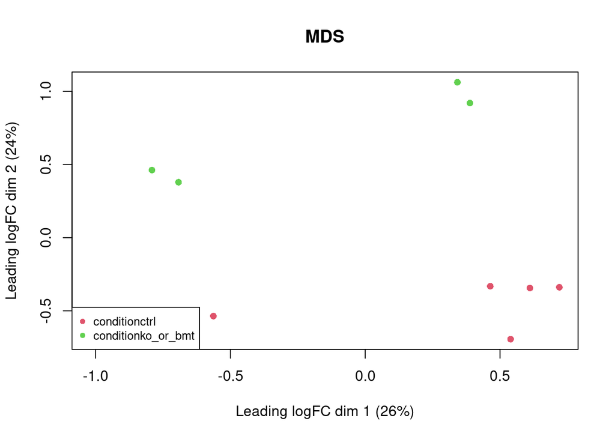

```r
condition <- as.factor(y$samples$condition)
#png(file.path(results_path, paste0("MDS_plot_", current_comparison, ".png")))
plotMDS(y, pch=16, col=c(2:8)[condition], main="MDS")
legend("bottomleft",
       legend=paste0("condition",levels(condition)),
       pch=16,
       col=2:8,
       cex=0.8)
```

```r
#dev.off()
```

Fit a GLM:

```r
# design matrix
design <- model.matrix(~0 + condition,
                       data = current_samples)
colnames(design) <- gsub("condition", "", colnames(design))

# estimate dispersion
# nb: consider estimateGLMRobustDisp if heavy outliers
y <- estimateDisp(y,
                  design,
                  robust = TRUE)

# fit glm
fit <- glmFit(y,
              design,
              robust=TRUE)
```

Pairwise LRT testing:

```r
conditions <- levels(factor(current_samples$condition))

# personal preference: reverse alphabetical factor order
conditions <- rev(conditions)

# initiate list
results_list <- list()

# nested loop for pairwise testing
for (i in 1:(length(conditions) - 1)) {
  for (j in (i + 1):length(conditions)) {
    # define pairs
    condition1 <- conditions[i]
    condition2 <- conditions[j]

    # define contrast
    contrast <- numeric(ncol(design))
    contrast[which(colnames(design) == condition1)] <- 1
    contrast[which(colnames(design) == condition2)] <- -1

    # testing with LRT
    lrt <- glmLRT(fit, contrast = contrast)

    # get results
    results <- topTags(lrt, n = Inf)$table

    # save to list
    comparison_name <- paste0(condition1, "_vs_", condition2)
    results_list[[comparison_name]] <- results

    # save to csv, including UP / DOWN subsets
    write.csv(
      results,
      file.path(results_path, paste0(comparison_name, "_ALL.csv"))
      )
    write.csv(
      results %>%
        filter(logFC > 0),
      file.path(results_path, paste0(comparison_name, "_UP.csv"))
      )
    write.csv(
      results %>%
        filter(logFC < 0),
      file.path(results_path, paste0(comparison_name, "_DOWN.csv"))
    )
  }
}
```

```r
print(head(results_list[["ko_or_bmt_vs_ctrl"]]))
```

```
##            logFC   logCPM       LR       PValue          FDR
## Mgst2   2.906048 6.131564 77.64931 1.230593e-18 6.951620e-15
## Mmp8    3.040964 5.205804 61.76697 3.866043e-15 1.091964e-11
## Itgam   2.621747 5.792481 60.91035 5.973397e-15 1.124791e-11
## Selenom 3.106139 6.317950 60.11478 8.948379e-15 1.263735e-11
## Prtn3   1.843890 9.963911 57.49332 3.391283e-14 3.831472e-11
## Ifitm6  2.415641 5.420978 56.54451 5.494046e-14 5.172645e-11
```